# Homework 5

Joe Dickerson

2025-02-21

```r
## packages
library(tidyverse)
library(faraway)
library(DescTools)
library(vcdExtra)
library(AMR)
data(melanoma)
```

1. Display the data in a two-way table. Make a mosaic plot and comment on the evidence for independence.

Based on the mosaic plot, it appears that there is some element of dependence on the head location. We see a much larger amount of freckles on head than indeterminate, nodular, and superficial. Superficial tumor also appears notably smaller. I have displayed the data in a few different ways for additional help with interpreting.

```r
ct <- xtabs(count ~ tumor + site, melanoma)

ct
```

```
##                site
## tumor           extremity head trunk
##   freckle              10   22     2
##   indeterminate        28   11    17
##   nodular              73   19    33
##   superficial         115   16    54
```

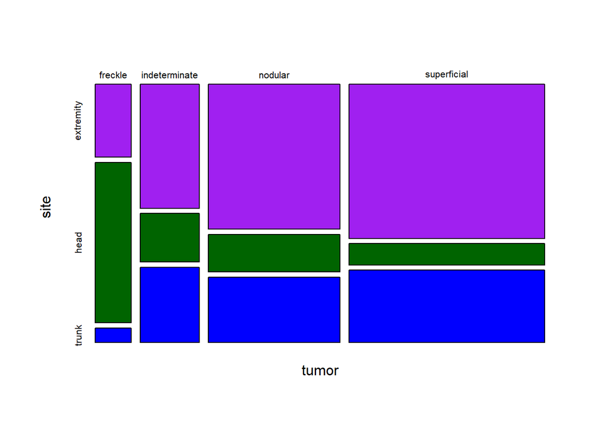

```r
mosaicplot(ct, color=c("purple", "darkgreen", "blue"), main=NULL)
```

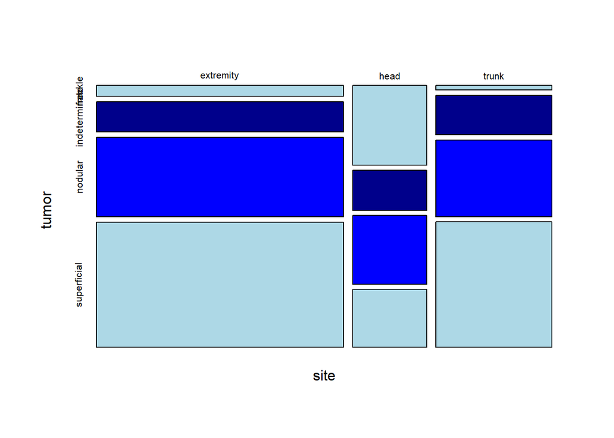

```r
mosaicplot(t(ct), color=c("lightblue", "darkblue", "blue"), main=NULL)
```

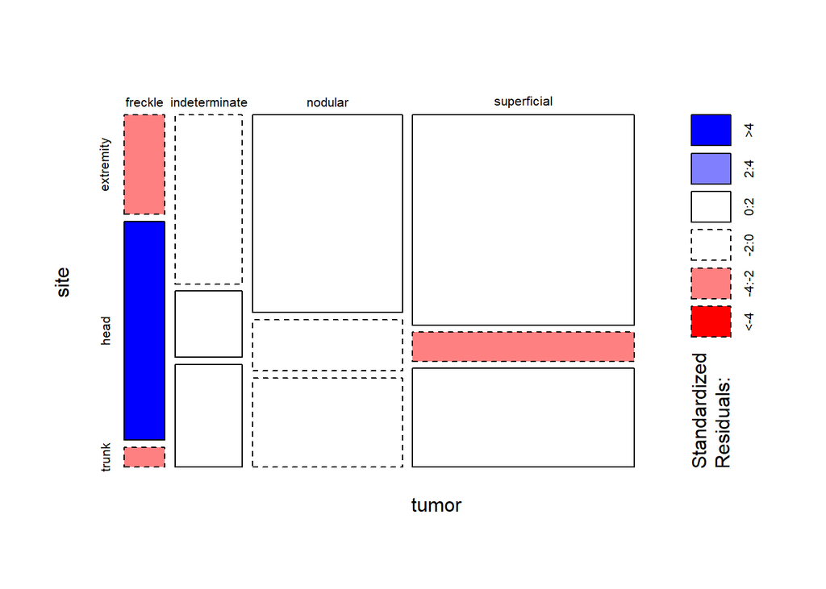

```r
mosaicplot(ct, color=FALSE, shade=TRUE, main=NULL)
```

2. Check for independence between site and tumor type using a Chi-squared test.

It appears that the null hypothesis is rejected, which would indicate there is dependence.

```r
chisq.test(ct)
```

```
##
##  Pearson's Chi-squared test
##
## data:  ct
## X-squared = 65.813, df = 6, p-value = 2.943e-12
```

3. Fit a Poisson GLM model and use it to check for independence.

We have a deviance of 51.795 on 6 degrees of freedom, which further suggests dependence. The null deviance is much higher at 295.2 on 11 degrees of freedom.

```r
glmod <- glm(count ~ tumor + site, family=poisson, melanoma)

summary(glmod)
```

```
##
## Call:
## glm(formula = count ~ tumor + site, family = poisson, data = melanoma)
##
## Coefficients:
##                    Estimate Std. Error z value Pr(>|z|)
## (Intercept)          2.9554     0.1770  16.696  < 2e-16 ***
## tumorindeterminate   0.4990     0.2174   2.295   0.0217 *
## tumornodular         1.3020     0.1934   6.731 1.68e-11 ***
## tumorsuperficial     1.6940     0.1866   9.079  < 2e-16 ***
## sitehead            -1.2010     0.1383  -8.683  < 2e-16 ***
## sitetrunk           -0.7571     0.1177  -6.431 1.27e-10 ***
## ---
## Signif. codes:  0 '***' 0.001 '**' 0.01 '*' 0.05 '.' 0.1 ' ' 1
##
## (Dispersion parameter for poisson family taken to be 1)
##
##     Null deviance: 295.203  on 11  degrees of freedom
## Residual deviance:  51.795  on  6  degrees of freedom
## AIC: 122.91
##
## Number of Fisher Scoring iterations: 5
```

```r
pchisq(deviance(glmod), df.residual(glmod), lower.tail = FALSE)
```

```
## [1] 2.050453e-09
```

4. Make a two-way table of the deviance residuals from the last model. Comment on the larger residuals.

The two-way table shows similar findings to the interpretation of the mosaic plot. Freckle and superficial are very large residuals for head.

```r
round(xtabs(residuals(glmod) ~ tumor + site, melanoma), 2)
```

```
##                site
## tumor           extremity  head trunk
##   freckle           -2.32  5.14 -2.83
##   indeterminate     -0.66  0.47  0.55
##   nodular            0.28 -0.50 -0.02
##   superficial        1.01 -3.05  0.70
```

5. Construct the correspondence plot. Interpret the plot.

As previously pointed out, we see a correspondence between freckle and head. We also see this with indeterminate and trunk. It appears that freckle and head have the strongest correspondence with each other, which seems to be confirmed by the two-way table in the previous problem.

[figure not shown]

```r
z <- xtabs(residuals(glmod, type="pearson") ~ tumor + site, melanoma)
svdz <- svd(z, 2, 2)
leftsv <- svdz$u %*% diag(sqrt(svdz$d[1:2]))
rightsv <- svdz$v %*% diag(sqrt(svdz$d[1:2]))
ll <- 1.1*max(abs(rightsv), abs(leftsv))
plot(rbind(leftsv, rightsv), asp=1, xlim=c(-1.25, 1.25), ylim=c(-1.25, 1.25), xlab="SV1", ylab="SV2", type = "n")
abline(h=0, v=0)
text(leftsv, dimnames(z)[[1]])
text(rightsv, dimnames(z)[[2]])
```

6. Omit all the head location data and repeat the test for independence. What does this indicate?

A G-test on the data set without the head location fails to reject the null of independence. It appears the remaining data is more independent with the absence of the head data. This is noteworthy as part of the analysis–it is important to know how select variables impact the entire model.

```r
df <- melanoma[5:12,]

ct2 <- xtabs(count ~ tumor + site, df)

g.test(ct2)
```

```
##
##  G-test of independence
##
## data:  ct2
## X-squared = 2.1647, p-value = 0.9039
```

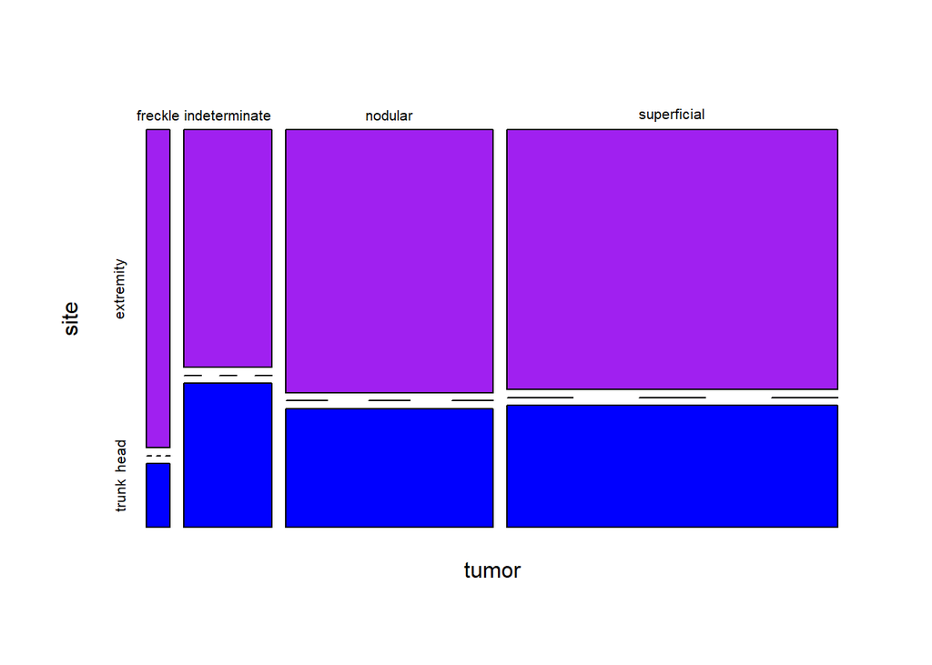

```r
mosaicplot(ct2, color=c("purple", "darkgreen", "blue"), main=NULL)
```

```r
glmod2 <- glm(count ~ tumor + site, family=poisson, df)

summary(glmod2)
```

```
##
## Call:
## glm(formula = count ~ tumor + site, family = poisson, data = df)
##
## Coefficients:
##                    Estimate Std. Error z value Pr(>|z|)
## (Intercept)          2.1003     0.2911   7.215 5.40e-13 ***
## tumorindeterminate   1.3218     0.3249   4.068 4.74e-05 ***
## tumornodular         2.1785     0.3046   7.153 8.51e-13 ***
## tumorsuperficial     2.6450     0.2987   8.854  < 2e-16 ***
## sitetrunk           -0.7571     0.1177  -6.431 1.27e-10 ***
## ---
## Signif. codes:  0 '***' 0.001 '**' 0.01 '*' 0.05 '.' 0.1 ' ' 1
##
## (Dispersion parameter for poisson family taken to be 1)
##
##     Null deviance: 237.2178  on 7  degrees of freedom
## Residual deviance:   2.1647  on 3  degrees of freedom
## AIC: 52.677
##
## Number of Fisher Scoring iterations: 4
```

```r
round(xtabs(residuals(glmod2) ~ tumor + site, df), 2)
```

```
##                site
## tumor           extremity  head trunk
##   freckle            0.62  0.00 -1.03
##   indeterminate     -0.48  0.00  0.67
##   nodular            0.10  0.00 -0.15
##   superficial        0.00  0.00  0.01
```

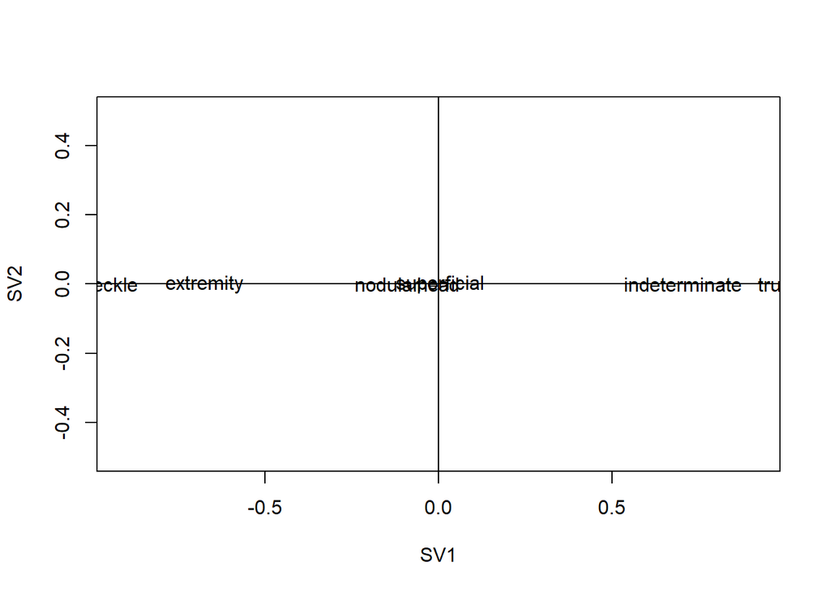

```r
z <- xtabs(residuals(glmod2, type="pearson") ~ tumor + site, df)
svdz <- svd(z, 2, 2)
leftsv <- svdz$u %*% diag(sqrt(svdz$d[1:2]))
rightsv <- svdz$v %*% diag(sqrt(svdz$d[1:2]))
ll <- 1.1*max(abs(rightsv), abs(leftsv))
plot(rbind(leftsv, rightsv), asp=1, xlim=c(-.5, .5), ylim=c(-.5, .5), xlab="SV1", ylab="SV2", type = "n")
abline(h=0, v=0)
text(leftsv, dimnames(z)[[1]])
text(rightsv, dimnames(z)[[2]])
```